# Stock Trend App

## Introduction

*This app is intended to provide an easy to use interface to lookup stock symbols from google finance, and provide trends as:*

- Stock price trend
- Stock volume trend
- Max/Min price for date range
- Max/Min volume for date range

## Stock Trend App

Stock trend app is hosted on shiny server. App link is as:

https://myrprojects.shinyapps.io/StockTrendApp/

## Lookup Stock Symbol

*To lookup stock tread, request can be configured with following inputs:*

- Enter ticker symbol (required)
- Select date range (required)
- Select inflation adjustment in price trend (optional)
- Plot price on log scale(optional)

## Quantmod package

This app utlizes quantmod package, which is Quantitative Financial Modelling & Trading Framework for R ,used to retreive data from google finance and inflation adjustment from fred.  
*Data Sources:* - Federal Reserve Bank of St. Louis FRED (11,000 economic series) - Google Finance (OHLC data)

*Quantmod functions can be referenced from:* - https://www.quantmod.com/documentation/00Index.html

## A sample call to FRED data

```r
library(quantmod)
options("getSymbols.warning4.0"=FALSE)
d = getSymbols('CPIAUCNS', src = 'FRED',auto.assign = FALSE)
str(d)
```

```
## An 'xts' object on 1913-01-01/2017-06-01 containing:
##   Data: num [1:1254, 1] 9.8 9.8 9.8 9.8 9.7 9.8 9.9 9.9 10 10 ...
##  - attr(*, "dimnames")=List of 2
##   ..$ : NULL
##   ..$ : chr "CPIAUCNS"
##   Indexed by objects of class: [Date] TZ: UTC
##   xts Attributes:
## List of 2
##  $ src    : chr "FRED"
##  $ updated: POSIXct[1:1], format: "2017-07-30 10:09:11"
```

## Visual representation

get stock data:

```r
data <- getSymbols(
            'JPM',
            src = "google",
            from = '2017-01-01',
            to = Sys.Date(),
            auto.assign = FALSE
        )
```

## chart series

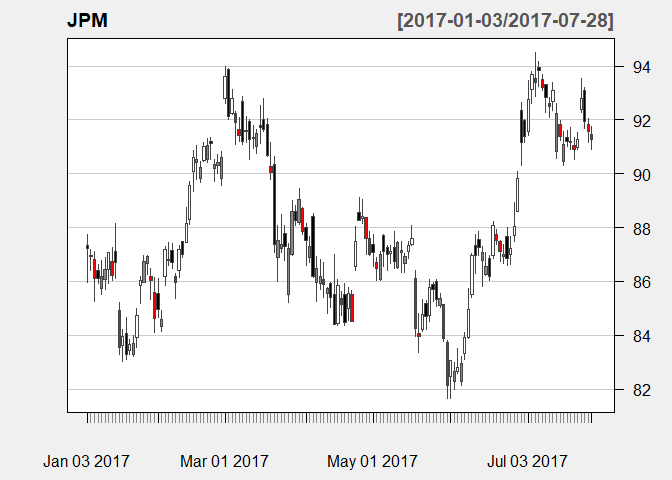

```r
chartSeries(
  data,
  theme = chartTheme("white"),
  type = "auto",
  TA = NULL,
  name = 'JPM',
  show.grid = TRUE,
  multi.col = TRUE
  )
```

## Shiny

This app utilizes Shiny, a web application framework for R, to create encapsulation and presentation of web interface for this app. For more details, please refer: - https://shiny.rstudio.com/